# Preprocess Text Documents (Sentiment Polarity Detection)

This Jupyter notebook file is created to preproces the text data samples used for the sentiment polarity detection. It is created separately from the model training file to divide the tasks and the notebook execution time, as the data samples is quite a large file with many documents within it, so preprocessing can take time.

# Import dependencies

```python
import matplotlib.pyplot as plt
import seaborn as sns
import pandas as pd
import numpy as np
import pickle
import re
```

# Load and explore dataset

This section is a part of the data understanding CRISP-DM, as well as removing columns that will not be useful for the data modelling phase.

```python
dataset = pd.read_csv('../datasets/amazon_foodreviews.csv')
```

```python
dataset
```

|  | Id | ProductId | UserId | ProfileName | HelpfulnessNumerator | HelpfulnessDenominator | Score | Time | Summary | Text |
| --- | --- | --- | --- | --- | --- | --- | --- | --- | --- | --- |
| 0 | 1 | B001E4KFG0 | A3SGXH7AUHU8GW | delmartian | 1 | 1 | 5 | 1303862400 | Good Quality Dog Food | I have bought several of the Vitality canned d... |
| 1 | 2 | B00813GRG4 | A1D87F6ZCVE5NK | dll pa | 0 | 0 | 1 | 1346976000 | Not as Advertised | Product arrived labeled as Jumbo Salted Peanut... |
| 2 | 3 | B000LQOCH0 | ABXLMWJIXXAIN | Natalia Corres "Natalia Corres" | 1 | 1 | 4 | 1219017600 | "Delight" says it all | This is a confection that has been around a fe... |
| 3 | 4 | B000UA0QIQ | A395BORC6FGVXV | Karl | 3 | 3 | 2 | 1307923200 | Cough Medicine | If you are looking for the secret ingredient i... |
| 4 | 5 | B006K2ZZ7K | A1UQRSCLF8GW1T | Michael D. Bigham "M. Wassir" | 0 | 0 | 5 | 1350777600 | Great taffy | Great taffy at a great price. There was a wid... |
| ... | ... | ... | ... | ... | ... | ... | ... | ... | ... | ... |
| 568449 | 568450 | B001EO7N10 | A28KG5XORO54AY | Lettie D. Carter | 0 | 0 | 5 | 1299628800 | Will not do without | Great for sesame chicken..this is a good if no... |
| 568450 | 568451 | B003S1WTCU | A3I8AFVPEE8KI5 | R. Sawyer | 0 | 0 | 2 | 1331251200 | disappointed | I'm disappointed with the flavor. The chocolat... |
| 568451 | 568452 | B004I613EE | A121AA1GQV751Z | pksd "pk_007" | 2 | 2 | 5 | 1329782400 | Perfect for our maltipoo | These stars are small, so you can give 10-15 o... |
| 568452 | 568453 | B004I613EE | A3IBEVCTXKNOH | Kathy A. Welch "katwel" | 1 | 1 | 5 | 1331596800 | Favorite Training and reward treat | These are the BEST treats for training and rew... |
| 568453 | 568454 | B001LR2CU2 | A3LGQPJCZVL9UC | srfell17 | 0 | 0 | 5 | 1338422400 | Great Honey | I am very satisfied ,product is as advertised,... |

568454 rows × 10 columns

```python
dataset = dataset.drop(columns=['Id', 'ProductId', 'UserId', 'ProfileName', 'HelpfulnessNumerator', 'HelpfulnessDenominator', 'Time'])
```

```python
dataset
```

|  | Score | Summary | Text |
| --- | --- | --- | --- |
| 0 | 5 | Good Quality Dog Food | I have bought several of the Vitality canned d... |
| 1 | 1 | Not as Advertised | Product arrived labeled as Jumbo Salted Peanut... |
| 2 | 4 | "Delight" says it all | This is a confection that has been around a fe... |
| 3 | 2 | Cough Medicine | If you are looking for the secret ingredient i... |
| 4 | 5 | Great taffy | Great taffy at a great price. There was a wid... |
| ... | ... | ... | ... |
| 568449 | 5 | Will not do without | Great for sesame chicken..this is a good if no... |
| 568450 | 2 | disappointed | I'm disappointed with the flavor. The chocolat... |
| 568451 | 5 | Perfect for our maltipoo | These stars are small, so you can give 10-15 o... |
| 568452 | 5 | Favorite Training and reward treat | These are the BEST treats for training and rew... |
| 568453 | 5 | Great Honey | I am very satisfied ,product is as advertised,... |

568454 rows × 3 columns

```python
len(dataset)
```

```
568454
```

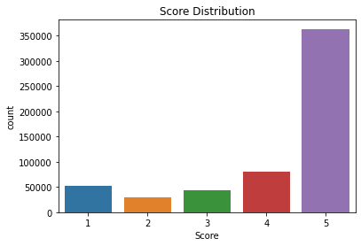

```python
ax = plt.axes()
sns.countplot(dataset.Score,ax=ax)
ax.set_title('Score Distribution')
plt.show()
```

# Preprocessing part

This section deals with the data preparation part where the texts are cleaned and any unnecessary characters such as certain punctuations and whitespaces are removed.

```python
dataset.Text[0]
```

```
'I have bought several of the Vitality canned dog food products and have found them all to be of good quality. The product looks more like a stew than a processed meat and it smells better. My Labrador is finicky and she appreciates this product better than  most.'
```

```python
dataset['Text'] = dataset.Text.apply(lambda x: x.lower()) # all reviews characters converts to lowercase
dataset['Text'] = dataset.Text.apply(lambda x: x.strip()) # remove whitespaces
dataset['Text'] = dataset.Text.apply(lambda x: re.sub(r'\d+', '', x))  # remove the numbers in reviews
dataset['Text'] = dataset.Text.apply(lambda x: re.sub(r'<br>', '', x)) # remove HTML line break
dataset['Text'] = dataset.Text.apply(lambda x: re.sub(r'<br />', '', x)) # remove HTML line break
dataset['Text'] = dataset.Text.apply(lambda x: re.sub(r"n't", ' not', x)) # expand 'not' compression
dataset['Text'] = dataset.Text.apply(lambda x: re.sub(r'[.,:;/\\$£&^*%"(){}\[\]<>#@…+-=_~|¬`]', '', x)) # remove the punctuations in reviews
dataset['Text'] = dataset.Text.apply(lambda x: re.sub(r"'", '', x)) # remove single quotes
dataset['Text'] = dataset.Text.apply(lambda x: re.sub(r' +', ' ', x)) # remove spaces that are more than one contiguously
```

```python
dataset['Text']
```

```
0         i have bought several of the vitality canned d...
1         product arrived labeled as jumbo salted peanut...
2         this is a confection that has been around a fe...
3         if you are looking for the secret ingredient i...
4         great taffy at a great price there was a wide ...
                                ...
568449    great for sesame chickenthis is a good if not ...
568450    im disappointed with the flavor the chocolate ...
568451    these stars are small so you can give of those...
568452    these are the best treats for training and rew...
568453    i am very satisfied product is as advertised i...
Name: Text, Length: 568454, dtype: object
```

# Get maximum words

Here the maximum words is retrieved in order to eyeball and determine the maximum length of sequences for one of the neural network hyperparameters.

```python
print(max(dataset['Text'], key=lambda x: len(x.split())))
```

```
fuzzy wuzzys summary somewhat recommended with reservations and only lukewarm fuzziespositives not too expensive compared to other bottled water although it is not cheap eithernegatives this bottled water products labeling product descriptions and health claims are misleadingat first glance this lit…
```

# Split train and test

This part splits the dataset to training samples and testing samples for the model to be evaluated against in order to retrieve the value accuracy of the model. For this learning purpose the test set is 20% of the whole sample set, leaving the rest 80% as the training set.

```python
train_size = int(len(dataset) - (len(dataset) * 0.2))
```

```python
train_data = dataset[:train_size]
test_data = dataset[train_size:]
```

```python
len(train_data)
```

```
454763
```

```python
len(test_data)
```

```
113691
```

# Dump as Pickle file

This phase dumps the preprocessed texts as pickle file to be used to train the model in the next phase

```python
pickle.dump(train_data['Text'], open('food_reviews_train.p', 'wb'))
pickle.dump(test_data['Text'], open('food_reviews_test.p', 'wb'))
```

```python
pickle.dump(train_data['Score'], open('food_reviews_train_scores.p', 'wb'))
pickle.dump(test_data['Score'], open('food_reviews_test_scores.p', 'wb'))
```